# Bubble Sort

Algoritma pengurutan yang pertama adalah Bubble Sort. Algoritma ini dikenal sebagai algoritma pengurutan yang membutuhkan waktu paling lama, hanya saja algoritma ini adalah algoritma pengurutan yang paling sederhana.

Bubble sort mengurutkan data dengan cara sebagai berikut :

1. data dibaca mulai dari paling kiri atau mulai dari indeks ke 0 (phyton) dari suatu list data
2. Bandingkan antara dua buah data yang saling berdekatan (antara data ke i dan i+1), tukar posisi jika data ke-i lebih besar dibandingkan data ke-i+1 (pengurutan secara ascending)
3. pindah satu posisi
4. lakukan perbandingan seperti langkah ke-2 dan pindah satu posisi kembali seperti langkah ke-3. Lakukan terus menerus sampai indeks data terakhir.
5. Setelah langkah ke-4 dilakukan, maka data yang berada di posisi paling kanan (indeks ke-N) adalah data terbesar .
6. Ulangi lagi langkah 1-4 dimulai dari indeks data ke 0 sampai dengan indeks ke N-1, N-2, ..., 0

Setiap iterasi berakhir, data yang terletak di posisi paling kanan adalah data yang paling besar, oleh karena itu algoritma ini disebut dengan 'bubble' karena data terbesar disetiap iterasi berakhir bergerak keatas seperti halnya gelembung. Berikut ilustrasi algoritma bubble sort pada tiap iterasi. Misalkan terdapat data [7, 2.5, 5. 10, 1].

Iterasi Kertama, bertujuan untuk memindahkan data terbesar, yaitu 10, ke posisi terakhir atau paling kanan dari list (karena proses pengurutan secara ascending (dari kecil-ke besar). Proses iterasi pertama ini dapat dilihat pada Gambar 1.

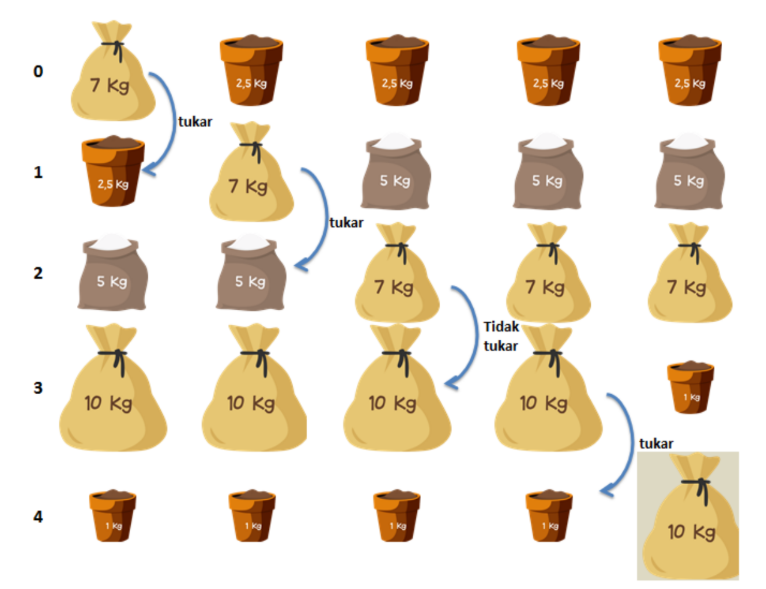

Iterasi Kedua, bertujuan untuk memindahkan data terbesar kedua, yaitu 7, agar menempati posisi tepat sebelum data 10, seperti yang terlihat pada Gambar 2.

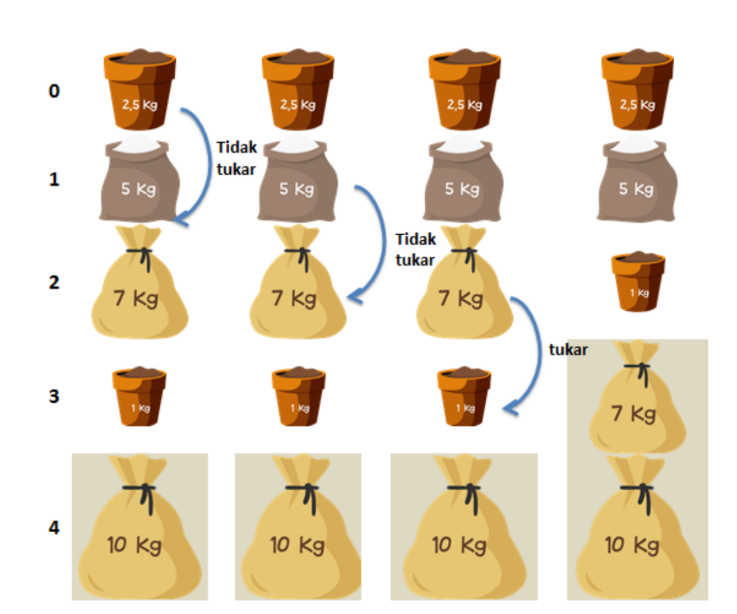

Iterasi Ketiga, bertujuan untuk memindahkan data terbesar ketiga, yaitu 5, untuk menempati posisi tepat sebelum data 7, seperti yang ditunjukkan pada Gambar 3.

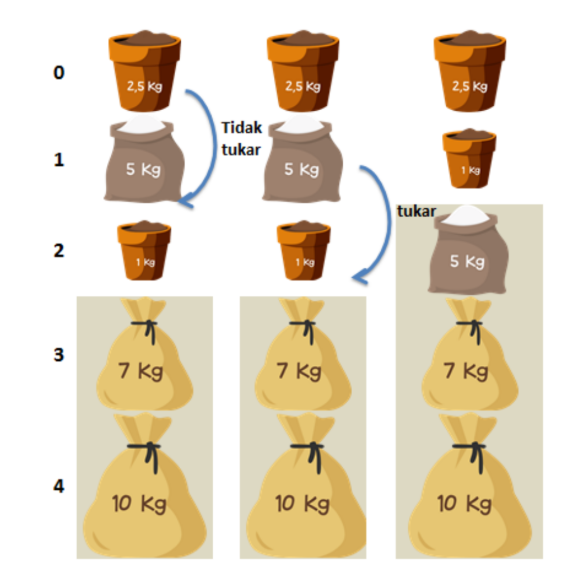

Proses ini dilakukan terus menerus sampai tidak ada data lagi yang akan dibandingkan. Data dalam keadaan terurut, dapat dilihat pada Gambar 4.

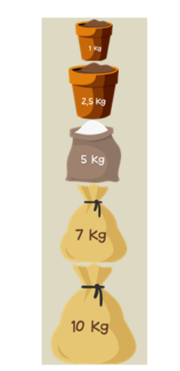

```python
def bubbleSort(listData):

    print('Data yang akan diurutkan :', listData)

    count = 0

    for outIter in range(len(listData)-1, -1, -1):

        print('outIter =', outIter)

        count = count + 1

        print('Iterasi ke-', count, ':')

        for i in range(outIter):

            if listData[i] > listData[i+1]:

                temp = listData[i]
                listData[i] = listData[i+1]
                listData[i+1] = temp

                # alternatif:
                # listData[i], listData[i+1] = listData[i+1], listData[i]

            print(outIter, '=', listData)

    print('Data urut =', listData)
```

```python
data = [5, 1, 8, 3, 2]

bubbleSort(data)
```

```
Data yang akan diurutkan : [5, 1, 8, 3, 2]
outIter = 4
Iterasi ke- 1 :
4 = [1, 5, 8, 3, 2]
4 = [1, 5, 8, 3, 2]
4 = [1, 5, 3, 8, 2]
4 = [1, 5, 3, 2, 8]
outIter = 3
Iterasi ke- 2 :
3 = [1, 5, 3, 2, 8]
3 = [1, 3, 5, 2, 8]
3 = [1, 3, 2, 5, 8]
outIter = 2
Iterasi ke- 3 :
2 = [1, 3, 2, 5, 8]
2 = [1, 2, 3, 5, 8]
outIter = 1
Iterasi ke- 4 :
1 = [1, 2, 3, 5, 8]
outIter = 0
Iterasi ke- 5 :
Data urut = [1, 2, 3, 5, 8]
```